# Project

## Problem Statement

The file task_data.csv contains an example data set that has been artificially generated. The set consists of 400 samples where for each sample there are 10 different sensor readings available. The samples have been divided into two classes where the class label is either 1 or -1. The class labels define to what particular class a particular sample belongs.

Your task is to rank the sensors according to their importance/predictive power with respect to the class labels of the samples. Your solution should be a Python script or a Jupyter notebook file that generates a ranking of the sensors from the provided CSV file. The ranking should be in decreasing order where the first sensor is the most important one.

```python
#importing the required packages
import numpy as np
import pandas as pd
import matplotlib.pyplot as plt
import seaborn as sns
from subprocess import check_output
%matplotlib inline
from sklearn.feature_selection import SelectFromModel
from sklearn.ensemble.forest import RandomForestClassifier
#reading the CSV File
dataset = pd.read_csv(r'C:\Users\Numan Ahmed\Documents\German Project\data.csv')
```

```python
df = pd.DataFrame(dataset)
```

```python
df
```

|  | sample index | class_label | sensor0 | sensor1 | sensor2 | sensor3 | sensor4 | sensor5 | sensor6 | sensor7 | sensor8 | sensor9 |
| --- | --- | --- | --- | --- | --- | --- | --- | --- | --- | --- | --- | --- |
| 0 | sample0 | 1.0 | 0.834251 | 0.726081 | 0.535904 | 0.214896 | 0.873788 | 0.767605 | 0.111308 | 0.557526 | 0.599650 | 0.665569 |
| 1 | sample1 | 1.0 | 0.804059 | 0.253135 | 0.869867 | 0.334285 | 0.604075 | 0.494045 | 0.833575 | 0.194190 | 0.014966 | 0.802918 |
| 2 | sample2 | 1.0 | 0.694404 | 0.595777 | 0.581294 | 0.799003 | 0.762857 | 0.651393 | 0.075905 | 0.007186 | 0.659633 | 0.831009 |
| 3 | sample3 | 1.0 | 0.783690 | 0.038780 | 0.285043 | 0.627305 | 0.800620 | 0.486340 | 0.827723 | 0.339807 | 0.731343 | 0.892359 |
| 4 | sample4 | 1.0 | 0.788835 | 0.174433 | 0.348770 | 0.938244 | 0.692065 | 0.377620 | 0.183760 | 0.616805 | 0.492899 | 0.930969 |
| ... | ... | ... | ... | ... | ... | ... | ... | ... | ... | ... | ... | ... |
| 395 | sample395 | -1.0 | 0.433150 | 0.816109 | 0.452945 | 0.065469 | 0.237093 | 0.719321 | 0.577969 | 0.085598 | 0.357115 | 0.070060 |
| 396 | sample396 | -1.0 | 0.339346 | 0.914610 | 0.097827 | 0.077522 | 0.484140 | 0.690568 | 0.420054 | 0.482845 | 0.395148 | 0.438641 |
| 397 | sample397 | -1.0 | 0.320118 | 0.444951 | 0.401896 | 0.970993 | 0.960264 | 0.138345 | 0.354927 | 0.230749 | 0.204612 | 0.558889 |
| 398 | sample398 | -1.0 | 0.059132 | 0.337426 | 0.772847 | 0.099038 | 0.966042 | 0.975086 | 0.532891 | 0.035839 | 0.258723 | 0.709958 |
| 399 | sample399 | -1.0 | 0.379778 | 0.460256 | 0.229257 | 0.768975 | 0.321882 | 0.118572 | 0.448964 | 0.546324 | 0.363127 | 0.176632 |

400 rows × 12 columns

```python
#selcting X and y for predicting the importance of features based on predictive power
drop_col = ['sample index','class_label']
X = df.drop(drop_col, axis = 1)
y = df.class_label
```

```python
X
```

|  | sensor0 | sensor1 | sensor2 | sensor3 | sensor4 | sensor5 | sensor6 | sensor7 | sensor8 | sensor9 |
| --- | --- | --- | --- | --- | --- | --- | --- | --- | --- | --- |
| 0 | 0.834251 | 0.726081 | 0.535904 | 0.214896 | 0.873788 | 0.767605 | 0.111308 | 0.557526 | 0.599650 | 0.665569 |
| 1 | 0.804059 | 0.253135 | 0.869867 | 0.334285 | 0.604075 | 0.494045 | 0.833575 | 0.194190 | 0.014966 | 0.802918 |
| 2 | 0.694404 | 0.595777 | 0.581294 | 0.799003 | 0.762857 | 0.651393 | 0.075905 | 0.007186 | 0.659633 | 0.831009 |
| 3 | 0.783690 | 0.038780 | 0.285043 | 0.627305 | 0.800620 | 0.486340 | 0.827723 | 0.339807 | 0.731343 | 0.892359 |
| 4 | 0.788835 | 0.174433 | 0.348770 | 0.938244 | 0.692065 | 0.377620 | 0.183760 | 0.616805 | 0.492899 | 0.930969 |
| ... | ... | ... | ... | ... | ... | ... | ... | ... | ... | ... |
| 395 | 0.433150 | 0.816109 | 0.452945 | 0.065469 | 0.237093 | 0.719321 | 0.577969 | 0.085598 | 0.357115 | 0.070060 |
| 396 | 0.339346 | 0.914610 | 0.097827 | 0.077522 | 0.484140 | 0.690568 | 0.420054 | 0.482845 | 0.395148 | 0.438641 |
| 397 | 0.320118 | 0.444951 | 0.401896 | 0.970993 | 0.960264 | 0.138345 | 0.354927 | 0.230749 | 0.204612 | 0.558889 |
| 398 | 0.059132 | 0.337426 | 0.772847 | 0.099038 | 0.966042 | 0.975086 | 0.532891 | 0.035839 | 0.258723 | 0.709958 |
| 399 | 0.379778 | 0.460256 | 0.229257 | 0.768975 | 0.321882 | 0.118572 | 0.448964 | 0.546324 | 0.363127 | 0.176632 |

400 rows × 10 columns

```python
y
```

```
0      1.0
1      1.0
2      1.0
3      1.0
4      1.0
      ...
395   -1.0
396   -1.0
397   -1.0
398   -1.0
399   -1.0
Name: class_label, Length: 400, dtype: float64
```

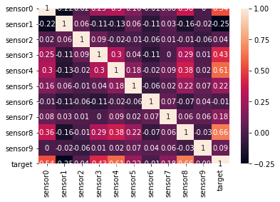

```python
sns.heatmap(X.assign(target = y).corr().round(2), annot = True)
```

## *Univariate Selection*

Statistical tests can be used to select those features that have the strongest relationship with the output variable.

The scikit-learn library provides the SelectKBest class that can be used with a suite of different statistical tests to select a specific number of features.

```python
import pandas as pd
import numpy as np
from sklearn.feature_selection import SelectKBest
from sklearn.feature_selection import chi2
```

```python
#apply SelectKBest class to extract top 10 best features
bestfeatures = SelectKBest(score_func=chi2, k=10)
fit = bestfeatures.fit(X,y)
dfscores = pd.DataFrame(fit.scores_)
dfcolumns = pd.DataFrame(X.columns)
#concat two dataframes for better visualization
featureScores = pd.concat([dfcolumns,dfscores],axis=1)
featureScores.columns = ['Features','Score']  #naming the dataframe columns
print(featureScores.nlargest(10,'Score'))  #print 10 best features
```

```
  Features      Score
8  sensor8  31.637080
4  sensor4  24.577241
0  sensor0  16.176762
3  sensor3  13.045426
1  sensor1   3.814755
5  sensor5   3.309987
7  sensor7   2.038891
9  sensor9   0.492408
2  sensor2   0.103099
6  sensor6   0.003760
```

## *Feature Importance*

You can get the feature importance of each feature of your dataset by using the feature importance property of the model.

Feature importance gives you a score for each feature of your data, the higher the score more important or relevant is the feature towards your output variable.

Feature importance is an inbuilt class that comes with Tree Based Classifiers, we will be using Extra Tree Classifier for extracting the top 10 features for the dataset.

```
[0.12824343 0.04773864 0.07001841 0.04591425 0.15205179 0.01729005
 0.2775783  0.02799633 0.20529526 0.02787354]
```

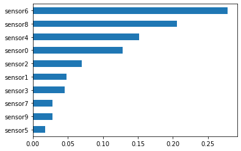

```python
from sklearn.ensemble import ExtraTreesClassifier
import matplotlib.pyplot as plt
model = ExtraTreesClassifier()
model.fit(X,y)
print(model.feature_importances_) #use inbuilt class feature_importances of tree based classifiers
#plot graph of feature importances for better visualization
feat_importances = pd.Series(model.feature_importances_, index=X.columns)
feat_importances.nsmallest(10).plot(kind='barh')
plt.show()
```

## XGBoost

Using theBuilt-in XGBoost Feature Importance Plot

```python
from numpy import loadtxt
from xgboost import XGBClassifier
from xgboost import plot_importance
from matplotlib import pyplot
model = XGBClassifier()
model.fit(X, y)
# feature importance
print(model.feature_importances_)
```

```
[0.05087308 0.02214793 0.02703828 0.00278934 0.08802208 0.
 0.13018082 0.         0.6610094  0.0179391 ]
```

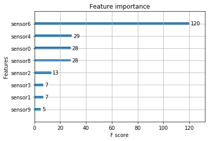

```python
plot_importance(model)
pyplot.show()
```

## Model Based Ranking(Random Forest)

We can fit a classfier to each feature and rank the predictive power. This method selects the most powerful features individually but ignores the predictive power when features are combined.

Random Forest Classifier is used in this case because it is robust, nonlinear, and doesn't require scaling.

```python
from sklearn.ensemble import RandomForestClassifier
from sklearn.model_selection import cross_val_score

clf = RandomForestClassifier(n_estimators = 100,
                           n_jobs = -1,
                           oob_score = True,
                           bootstrap = True, random_state=42)

scores = []
num_features = len(X.columns)
for i in range(num_features):
    col = X.columns[i]
    score = np.mean(cross_val_score(clf, X[col].values.reshape(-1,1), y, cv=10))
    scores.append((float(score)*100, col))

print(sorted(scores, reverse = True))
```

```
[(99.75, 'sensor6'), (82.75, 'sensor1'), (78.99999999999999, 'sensor8'), (75.25, 'sensor2'), (72.5, 'sensor4'), (67.75000000000001, 'sensor0'), (62.5, 'sensor5'), (56.25, 'sensor9'), (55.49999999999999, 'sensor3'), (48.75000000000001, 'sensor7')]
```

```python
data = pd.DataFrame(scores)
```

```python
scores
```

```
[(67.75000000000001, 'sensor0'),
 (82.75, 'sensor1'),
 (75.25, 'sensor2'),
 (55.49999999999999, 'sensor3'),
 (72.5, 'sensor4'),
 (62.5, 'sensor5'),
 (99.75, 'sensor6'),
 (48.75000000000001, 'sensor7'),
 (78.99999999999999, 'sensor8'),
 (56.25, 'sensor9')]
```

```python
from sklearn.ensemble import RandomForestClassifier

clf = RandomForestClassifier()
clf.fit(X,y)
```

```
RandomForestClassifier(bootstrap=True, class_weight=None, criterion='gini',
                       max_depth=None, max_features='auto', max_leaf_nodes=None,
                       min_impurity_decrease=0.0, min_impurity_split=None,
                       min_samples_leaf=1, min_samples_split=2,
                       min_weight_fraction_leaf=0.0, n_estimators=10,
                       n_jobs=None, oob_score=False, random_state=None,
                       verbose=0, warm_start=False)
```

```python
def print_best_worst (scores):
    scores = sorted(scores, reverse = True)

    print("The 5 Best features selected by this method are :")
    for i in range(5):
        print(scores[i][1])

    print ("The 5 Worst features selected by this method are :")
    for i in range(5):
        print(scores[len(scores)-1-i][1])
```

```python
scores = []
for i in range(num_features):
    scores.append((clf.feature_importances_[i],X.columns[i]))

print_best_worst(scores)
```

```
The 5 Best features selected by this method are :
sensor6
sensor4
sensor8
sensor2
sensor0
The 5 Worst features selected by this method are :
sensor7
sensor9
sensor3
sensor5
sensor1
```

## Permutation Importance

```python
import eli5
from eli5.sklearn import PermutationImportance

perm = PermutationImportance(clf, random_state=1).fit(X, y)
eli5.show_weights(perm, feature_names = X.columns.tolist())
```

| Weight | Feature |
| --- | --- |
| 0.4085 ± 0.0493 | sensor6 |
| 0.0050 ± 0.0045 | sensor4 |
| 0.0035 ± 0.0024 | sensor2 |
| 0.0020 ± 0.0037 | sensor8 |
| 0.0010 ± 0.0024 | sensor5 |
| 0.0005 ± 0.0020 | sensor1 |
| 0.0005 ± 0.0020 | sensor0 |
| 0 ± 0.0000 | sensor9 |
| 0 ± 0.0000 | sensor7 |
| 0 ± 0.0000 | sensor3 |

```python
def imp_fi(column_names, importances):
    fi = pd.DataFrame({'feature': column_names,
                       'feature_importance': importances}) \
           .sort_values('feature_importance', ascending = False) \
           .reset_index(drop = True)
    return df
```

```python
def var_imp_plot(imp_fi, title):
    imp_fi.columns = ['feature', 'feature_importance']
    sns.barplot(x = 'feature_importance', y = 'feature', data = imp_fi, orient = 'h', color = 'red') \
       .set_title(title, fontsize = 20)
```

```python
from sklearn.ensemble import RandomForestRegressor

rf = RandomForestRegressor(n_estimators = 100,
                           n_jobs = -1,
                           oob_score = True,
                           bootstrap = True,
                           random_state = 42)
rf.fit(X, y)
```

```
RandomForestRegressor(bootstrap=True, criterion='mse', max_depth=None,
                      max_features='auto', max_leaf_nodes=None,
                      min_impurity_decrease=0.0, min_impurity_split=None,
                      min_samples_leaf=1, min_samples_split=2,
                      min_weight_fraction_leaf=0.0, n_estimators=100, n_jobs=-1,
                      oob_score=True, random_state=42, verbose=0,
                      warm_start=False)
```

```python
from sklearn.metrics import r2_score
from rfpimp import permutation_importances

def r2(rf, X, y):
    return r2_score(y, rf.predict(X))

perm_imp_rfpimp = permutation_importances(rf, X, y, r2)
```

```python
from treeinterpreter import treeinterpreter as ti, utils

selected_rows = [0, 200]
selected_df = X.iloc[selected_rows,:].values
prediction, bias, contributions = ti.predict(rf, selected_df)

for i in range(len(selected_rows)):
    print("Row", selected_rows[i])
    print("Prediction:", prediction[i][0], 'Actual Value:', y[selected_rows[i]])
    print("Bias (trainset mean)", bias[i])
    print("Feature contributions:")
    for c, feature in sorted(zip(contributions[i],
                                 X.columns),
                             key=lambda x: -abs(x[0])):
        print(feature, round(c, 2))
    print("-"*20)
```

```
Row 0
Prediction: 1.0 Actual Value: 1.0
Bias (trainset mean) 0.00019999999999999998
Feature contributions:
sensor8 0.8
sensor0 0.07
sensor4 0.07
sensor1 0.02
sensor2 0.02
sensor5 0.0
sensor3 0.0
sensor6 0.0
sensor7 0.0
sensor9 0.0
--------------------
Row 200
Prediction: -1.0 Actual Value: -1.0
Bias (trainset mean) 0.00019999999999999998
Feature contributions:
sensor8 -0.71
sensor6 -0.27
sensor4 -0.03
sensor0 0.0
sensor1 0.0
sensor2 0.0
sensor3 0.0
sensor5 0.0
sensor7 0.0
sensor9 0.0
--------------------
```

## LIME

Local Interpretable Model-agnostic Explanations is a technique explaining the predictions of any classifier/regressor in an interpretable and faithful manner. To do so, an explanation is obtained by locally approximating the selected model with an interpretable one (such as linear models with regularisation or decision trees). The interpretable models are trained on small perturbations (adding noise) of the original observation (row in case of tabular data), thus they only provide a good local approximation.

```python
import lime
import lime.lime_tabular

explainer = lime.lime_tabular.LimeTabularExplainer(X.values,
                                                   mode = 'regression',
                                                   feature_names = X.columns,
                                                   categorical_features = [3],
                                                   categorical_names = ['CHAS'],
                                                   discretize_continuous = True)

np.random.seed(42)
exp = explainer.explain_instance(X.values[399], rf.predict, num_features = 10)
exp.show_in_notebook(show_all=False) #only the features used in the explanation are displayed

exp = explainer.explain_instance(X.values[399], rf.predict, num_features = 10)
exp.show_in_notebook(show_all=False)
```

[output not shown]

## Conclusion

[output not shown]

## References

*https://www.kaggle.com/dkim1992/feature-selection-ranking*https://www.kaggle.com/paultimothymooney/feature-selection-with-permutation-importance *https://towardsdatascience.com/explaining-feature-importance-by-example-of-a-random-forest-d9166011959e